# Question

La grafica muestra informacion de las poblaciones de 5 paises desde 2000 hasta 2020.

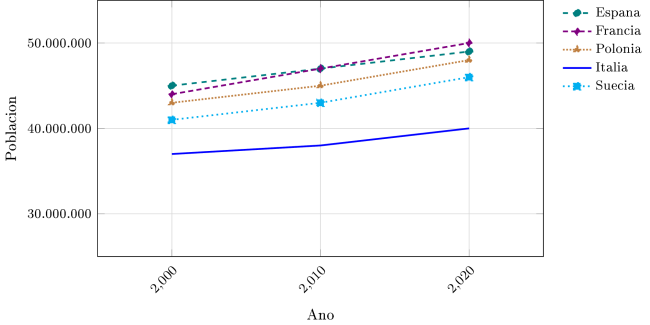

Segun la grafica, ?cual pais tuvo la mayor poblacion en 2020?

# Solution

Para responder esta pregunta, debemos comparar las poblaciones de los 5 paises al final del periodo (2020).

**Analisis del grafico:**

Observando el valor de cada linea en el extremo derecho del grafico (ano 2020):

- Espana: 49.000.000 habitantes
- Francia: 50.000.000 habitantes
- Polonia: 48.000.000 habitantes
- Italia: 40.000.000 habitantes
- Suecia: 46.000.000 habitantes

**Respuesta:** El pais con mayor poblacion en 2020 es **Francia** con 50.000.000 habitantes.

# Meta-information

exname: poblaciones_paises_series_temporales extype: schoice exsolution: 0010 exshuffle: FALSE exsection: Estadistica/Series_Temporales/Interpretacion_Graficos